# MSDS 6372 Project 1: EDA

Maureen Stolberg

June 2, 2019

## Predicting Wine Preferences based on it’s Physicochemical Properties

**Citation Request:**

This dataset is public available for research. The details are described in [Cortez et al., 2009]. Please include this citation if you plan to use this database:

P. Cortez, A. Cerdeira, F. Almeida, T. Matos and J. Reis. Modeling wine preferences by data mining from physicochemical properties. In Decision Support Systems>, Elsevier, 47(4):547-553. ISSN: 0167-9236.

Available at: https://archive.ics.uci.edu/ml/datasets/Wine+Quality

For more information, read [Cortez et al., 2009].

## Data Description

The datasets are publicly available for research purposes and the details are described in [Cortez et al., 2009]. I collected the data from the UCI repository website (https://archive.ics.uci.edu/ml/datasets/Wine+Quality). Dataset is large enough to rely on its result ( with 4898 white and 1599 red entries ) of Vinho Verde (Portugal Wine Company from the northwest region of Portugal) samples are considered:

. winequality-red.csv - red wine preference samples . winequality-white.csv - white wine preference samples

These data sets include physicochemical and sensory related data to red and white Vinho Verde wine sample. The data were collected from May/2004 to February/2007 using only protected designation of origin samples that were tested at the official certification entity (CVRVV). The CVRVV is an inter-professional organization with the goal of improving the quality and marketing of Vinho Verde. The data were recorded by a computerized system (iLab), which automatically manages the process of wine sample testing from producer requests to the laboratory and sensory analysis. Each entry denotes a given test (analytical or sensory) and the final database was exported into a single sheet (.csv).

**Description of attributes:**

**Fixed acidity:** most acids involved with wine or fixed or nonvolatile (do not evaporate readily)

**Volatile acidity:** the amount of acetic acid in wine, which at too high of levels can lead to an unpleasant, vinegar taste.

**Citric acid:** found in small quantities, citric acid can add ‘freshness’ and flavor to wines

**Residual sugar:** the amount of sugar remaining after fermentation stops, it’s rare to find wines with less than 1 gram/liter and wines with greater than 45 grams/liter are considered sweet.

**Chlorides:** the amount of salt in the wine

**Free sulfur dioxide:** the free form of SO2 exists in equilibrium between molecular SO2 (as a dissolved gas) and bisulfite ion; it prevents microbial growth and the oxidation of wine

**Total sulfur dioxide:** amount of free and bound forms of S02; in low concentrations, SO2 is mostly undetectable in wine, but at free SO2 concentrations over 50 ppm, SO2 becomes evident in the nose and taste of wine

**Density:** the density of water is close to that of water depending on the percent alcohol and sugar content

**pH:** describes how acidic or basic a wine is on a scale from 0 (very acidic) to 14 (very basic); most wines are between 3-4 on the pH scale

**Sulphates:** a wine additive which can contribute to sulfur dioxide gas (S02) levels, wich acts as an antimicrobial and antioxidant

**Alcohol:** the percent alcohol content of the wine

**Quality:** output variable (based on sensory data, score between 0 and 10)

## Univariate Data Summary Statistics

**Data Summary**

```
##  fixed.acidity    volatile.acidity  citric.acid     residual.sugar
##  Min.   : 3.800   Min.   :0.0800   Min.   :0.0000   Min.   : 0.600
##  1st Qu.: 6.400   1st Qu.:0.2300   1st Qu.:0.2500   1st Qu.: 1.800
##  Median : 7.000   Median :0.2900   Median :0.3100   Median : 3.000
##  Mean   : 7.215   Mean   :0.3397   Mean   :0.3186   Mean   : 5.443
##  3rd Qu.: 7.700   3rd Qu.:0.4000   3rd Qu.:0.3900   3rd Qu.: 8.100
##  Max.   :15.900   Max.   :1.5800   Max.   :1.6600   Max.   :65.800
##
##    chlorides       free.sulfurdioxide total.sulfurdioxide    density
##  Min.   :0.00900   Min.   :  1.00     Min.   :  6.0       Min.   :0.9871
##  1st Qu.:0.03800   1st Qu.: 17.00     1st Qu.: 77.0       1st Qu.:0.9923
##  Median :0.04700   Median : 29.00     Median :118.0       Median :0.9949
##  Mean   :0.05603   Mean   : 30.53     Mean   :115.7       Mean   :0.9947
##  3rd Qu.:0.06500   3rd Qu.: 41.00     3rd Qu.:156.0       3rd Qu.:0.9970
##  Max.   :0.61100   Max.   :289.00     Max.   :440.0       Max.   :1.0390
##
##        ph          sulphates         alcohol         quality
##  Min.   :2.720   Min.   :0.2200   Min.   : 8.00   Min.   :3.000
##  1st Qu.:3.110   1st Qu.:0.4300   1st Qu.: 9.50   1st Qu.:5.000
##  Median :3.210   Median :0.5100   Median :10.30   Median :6.000
##  Mean   :3.219   Mean   :0.5313   Mean   :10.49   Mean   :5.818
##  3rd Qu.:3.320   3rd Qu.:0.6000   3rd Qu.:11.30   3rd Qu.:6.000
##  Max.   :4.010   Max.   :2.0000   Max.   :14.90   Max.   :9.000
##
##  wine.category Quality.Factor wine.category.f
##  red  :1599    3:  30         red  :1599
##  white:4898    4: 216         white:4898
##                5:2138
##                6:2836
##                7:1079
##                8: 193
##                9:   5
```

**Descriptive Statistics (Full Dataset)**

```
## # A tibble: 12 x 6
##    variable            skewness     mean    p25     p50     p75
##    <chr>                  <dbl>    <dbl>  <dbl>   <dbl>   <dbl>
##  1 chlorides            5.40      0.0560  0.038   0.047   0.065
##  2 sulphates            1.80      0.531   0.43    0.51    0.6
##  3 fixed.acidity        1.72      7.22    6.4     7       7.7
##  4 volatile.acidity     1.50      0.340   0.23    0.290   0.4
##  5 residual.sugar       1.44      5.44    1.8     3       8.1
##  6 free.sulfurdioxide   1.22     30.5    17      29      41
##  7 alcohol              0.566    10.5     9.5    10.3    11.3
##  8 density              0.504     0.995   0.992   0.995   0.997
##  9 citric.acid          0.472     0.319   0.25    0.31    0.39
## 10 ph                   0.387     3.22    3.11    3.21    3.32
## 11 quality              0.190     5.82    5       6       6
## 12 total.sulfurdioxide -0.00118 116.     77     118     156
```

**Red vs. White Wine: Descriptive Statistics**

```
## # A tibble: 24 x 7
##    variable            wine.category skewness    mean    p25    p50    p75
##    <chr>               <fct>            <dbl>   <dbl>  <dbl>  <dbl>  <dbl>
##  1 volatile.acidity    red              0.672   0.528   0.39   0.52   0.64
##  2 volatile.acidity    white            1.58    0.278   0.21   0.26   0.32
##  3 total.sulfurdioxide red              1.52   46.5    22     38     62
##  4 total.sulfurdioxide white            0.391 138.    108    134    167
##  5 sulphates           red              2.43    0.658   0.55   0.62   0.73
##  6 sulphates           white            0.977   0.490   0.41   0.47   0.55
##  7 residual.sugar      red              4.54    2.54    1.9    2.2    2.6
##  8 residual.sugar      white            1.08    6.39    1.7    5.2    9.9
##  9 quality             red              0.218   5.64    5      6      6
## 10 quality             white            0.156   5.88    5      6      6
## # ... with 14 more rows
```

## Normality Review

### Scatterplot Matrix

**Red and White Wine dataset combined**

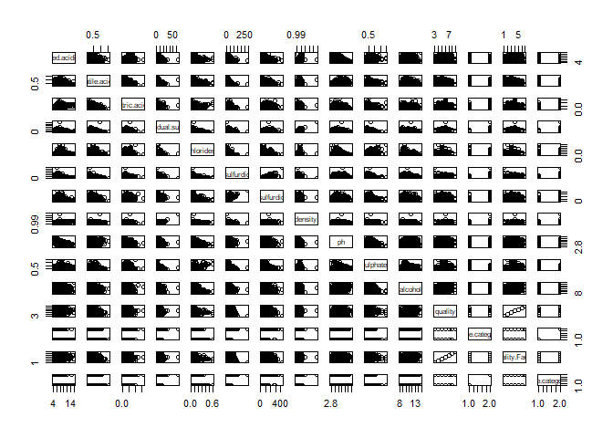

**Red Wine Only**

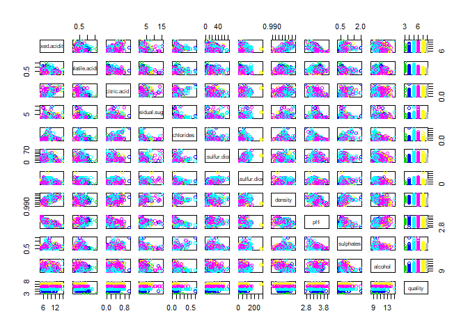

**White Wine Only**

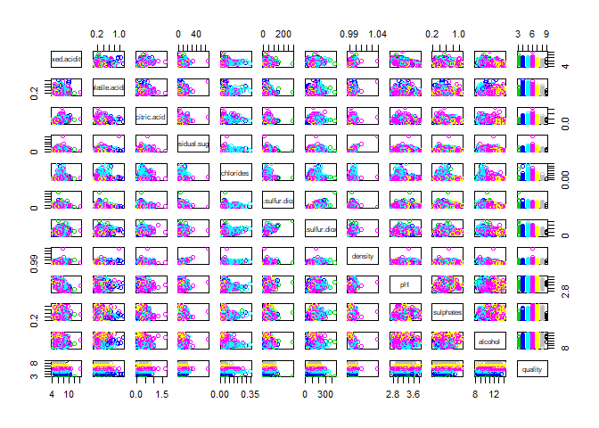

### Distribution Plots (based on original data)

Where: - Blue line represents the mean - Dark magenta line represents the median - Dashed line represents the 25th and 75th percentile

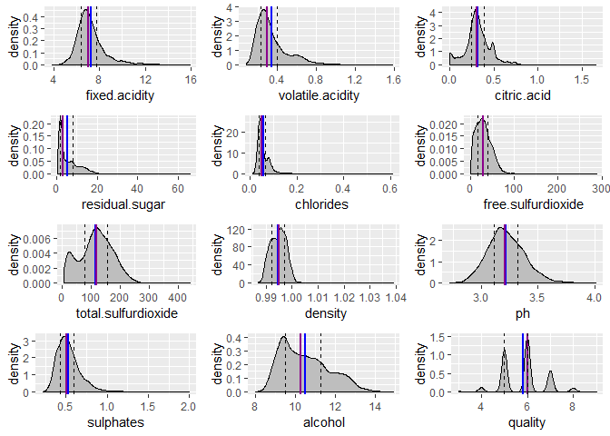

Review Variable transformation options to determine if data should be transformed prior to model creation.

Let:  
- origin represents normality based on raw unadjusted data - Log represents normality based on log transformed data - sqrt represents normality based on the square root of original data

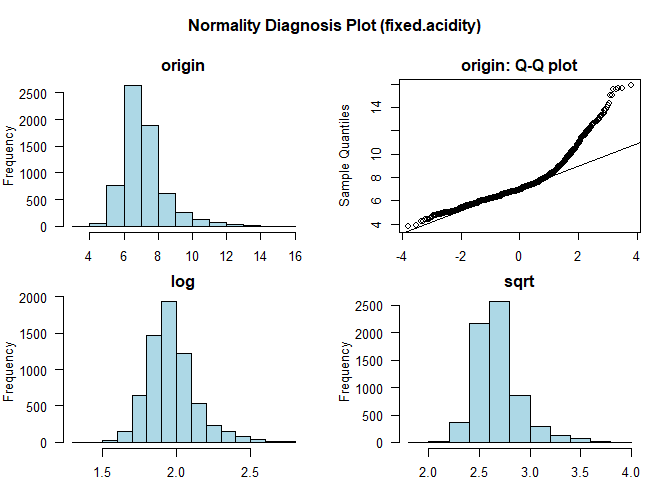

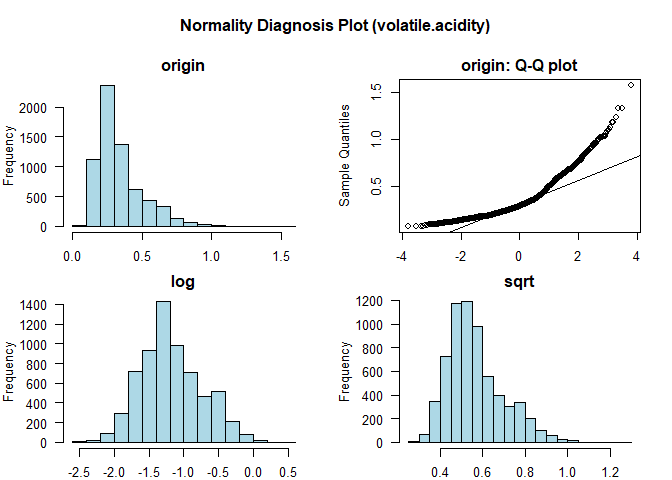

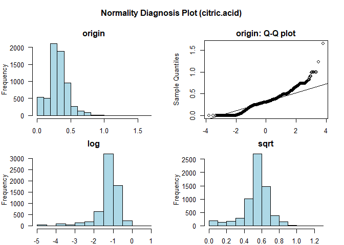

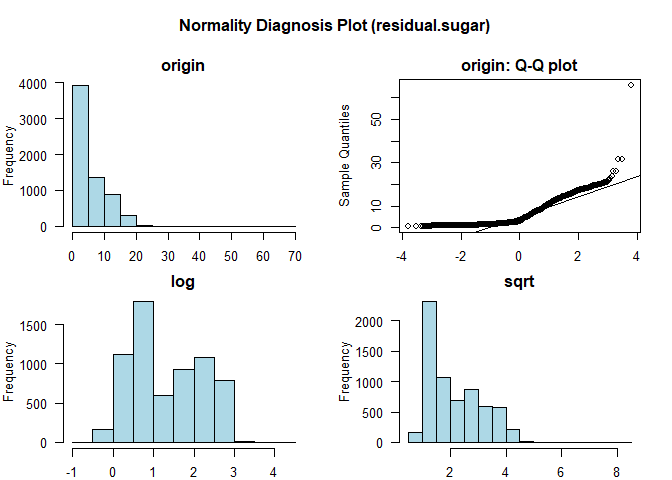

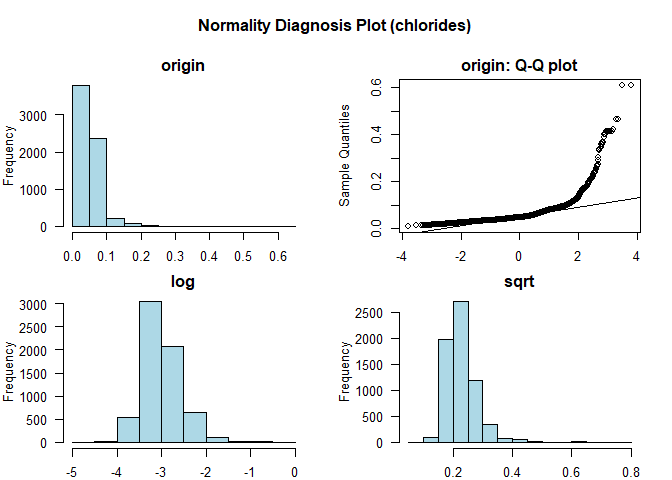

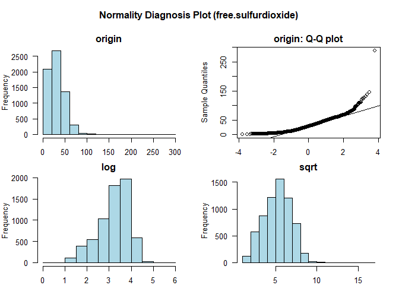

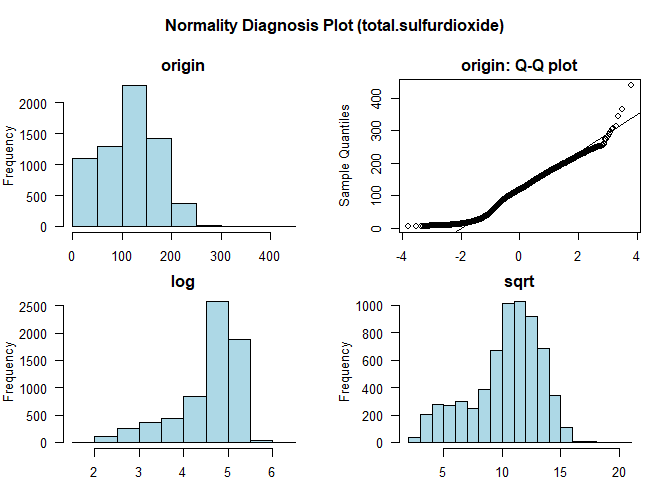

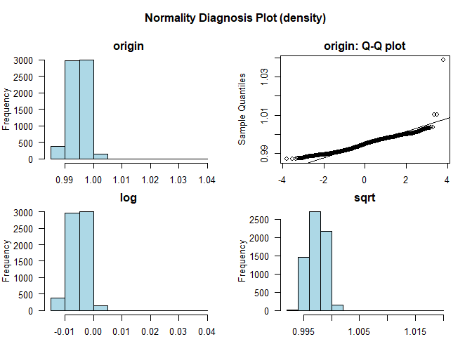

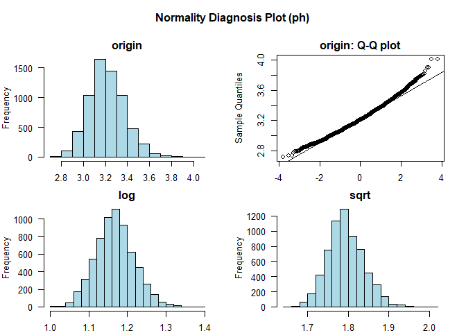

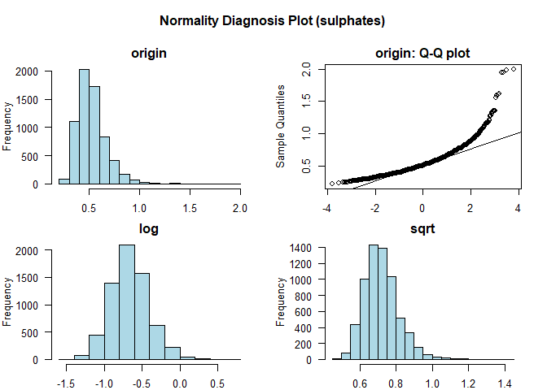

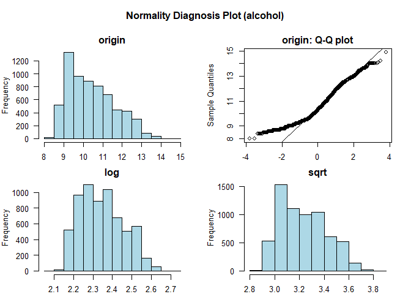

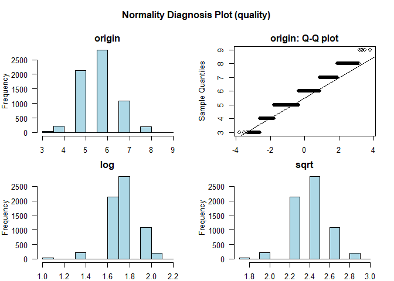

## Relationship Assessment

**Total Wine Inventory Review (Red + White)**

Lets explore how thte potential explanatory variables may be correlated to the response.

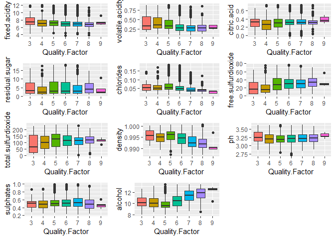

**Red Vs. White Wine Review**

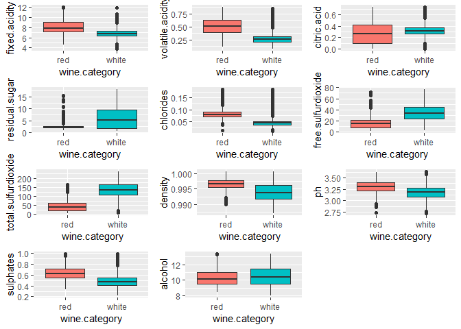

### Correlation Matrix

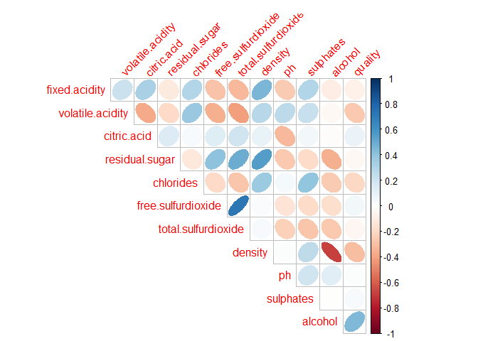